# Titanic Analysis

```python
import pandas as pd
import numpy as np
import seaborn as sns
import matplotlib.pyplot as plt
import statsmodels.api as sm
import statsmodels.formula.api as smf
import scipy as sp
%matplotlib inline
```

### 1. Introduction

This dataset contains demographics and passenger information from 891 of the 2224 passengers and crew on board the Titanic. The data include variables as follows:

Passengerid: One for each individual  
Survived: Whether this individual was survived or not (0 = No; 1 = Yes)  
Pclass: Passenger Class (1 = 1st; 2 = 2nd; 3 = 3rd)  
Name: Each passenger's name  
Sex: Each passenger's sex  
Age: Each passenger's age  
SibSp: Number of Siblings/Spouses Aboard  
Parch: Number of Parents/Children Aboard  
Ticket: Each passenger's ticket Number  
Fare: Each passenger's passenger Fare  
Cabin: Each passenger's cabin  
Embarked: Each passenger's port of Embarkation (C = Cherbourg; Q = Queenstown; S = Southampton)

The aim of this project is to see which factor(s) could predict the survival of people on titanic. Therefore, I am going to explore the relationship between people's survival and other variables using correlations for the first step, then select the most related variables to predict people's survival in a logistic regresson model, given that 'Survived' is binary. Meanwhile, the correlation between the possible predictors will also be considered to avoid multicollinearity among predictors. I expect that sex, passengers' class should be strong predictors for survival, for it is like a social norm that in dangerous environments men should protect women, and rich people usually have more priviliges than poor people.

### 2. Read in the file

```python
titanic = pd.read_csv('titanic-data.csv')
```

```python
titanic.head()
```

|  | PassengerId | Survived | Pclass | Name | Sex | Age | SibSp | Parch | Ticket | Fare | Cabin | Embarked |
| --- | --- | --- | --- | --- | --- | --- | --- | --- | --- | --- | --- | --- |
| 0 | 1 | 0 | 3 | Braund, Mr. Owen Harris | male | 22.0 | 1 | 0 | A/5 21171 | 7.2500 | NaN | S |
| 1 | 2 | 1 | 1 | Cumings, Mrs. John Bradley (Florence Briggs Th... | female | 38.0 | 1 | 0 | PC 17599 | 71.2833 | C85 | C |
| 2 | 3 | 1 | 3 | Heikkinen, Miss. Laina | female | 26.0 | 0 | 0 | STON/O2. 3101282 | 7.9250 | NaN | S |
| 3 | 4 | 1 | 1 | Futrelle, Mrs. Jacques Heath (Lily May Peel) | female | 35.0 | 1 | 0 | 113803 | 53.1000 | C123 | S |
| 4 | 5 | 0 | 3 | Allen, Mr. William Henry | male | 35.0 | 0 | 0 | 373450 | 8.0500 | NaN | S |

### 3. Descriptive Statistics for Each Variable

#### 3.1 General Descriptive Statistics

```python
titanic.describe()
```

|  | PassengerId | Survived | Pclass | Age | SibSp | Parch | Fare |
| --- | --- | --- | --- | --- | --- | --- | --- |
| count | 891.000000 | 891.000000 | 891.000000 | 714.000000 | 891.000000 | 891.000000 | 891.000000 |
| mean | 446.000000 | 0.383838 | 2.308642 | 29.699118 | 0.523008 | 0.381594 | 32.204208 |
| std | 257.353842 | 0.486592 | 0.836071 | 14.526497 | 1.102743 | 0.806057 | 49.693429 |
| min | 1.000000 | 0.000000 | 1.000000 | 0.420000 | 0.000000 | 0.000000 | 0.000000 |
| 25% | 223.500000 | 0.000000 | 2.000000 | 20.125000 | 0.000000 | 0.000000 | 7.910400 |
| 50% | 446.000000 | 0.000000 | 3.000000 | 28.000000 | 0.000000 | 0.000000 | 14.454200 |
| 75% | 668.500000 | 1.000000 | 3.000000 | 38.000000 | 1.000000 | 0.000000 | 31.000000 |
| max | 891.000000 | 1.000000 | 3.000000 | 80.000000 | 8.000000 | 6.000000 | 512.329200 |

```python
titanic['Sex'].value_counts()
```

```
male      577
female    314
Name: Sex, dtype: int64
```

```python
sum(pd.isnull(titanic['Sex']))
```

```
0
```

```python
titanic['Embarked'].value_counts()
```

```
S    644
C    168
Q     77
Name: Embarked, dtype: int64
```

```python
sum(pd.isnull(titanic['Embarked']))
```

```
2
```

From the table and counts above, we can see that there are 891 passengers in the dataset, and the information of age is missing for 177 of them, the information of embarked is missing for 2 of them. The passengerid, name, cabin and ticket are all nominal variables, so the statistics of these variables were not calculated. So next I will check whether the data with no missing values has a same pattern to the overall data. If so, I can just delete the data with missing values.

```python
subdata = titanic[titanic['Age'].notnull() & titanic['Embarked'].notnull()]
subdata.head()
```

|  | PassengerId | Survived | Pclass | Name | Sex | Age | SibSp | Parch | Ticket | Fare | Cabin | Embarked |
| --- | --- | --- | --- | --- | --- | --- | --- | --- | --- | --- | --- | --- |
| 0 | 1 | 0 | 3 | Braund, Mr. Owen Harris | male | 22.0 | 1 | 0 | A/5 21171 | 7.2500 | NaN | S |
| 1 | 2 | 1 | 1 | Cumings, Mrs. John Bradley (Florence Briggs Th... | female | 38.0 | 1 | 0 | PC 17599 | 71.2833 | C85 | C |
| 2 | 3 | 1 | 3 | Heikkinen, Miss. Laina | female | 26.0 | 0 | 0 | STON/O2. 3101282 | 7.9250 | NaN | S |
| 3 | 4 | 1 | 1 | Futrelle, Mrs. Jacques Heath (Lily May Peel) | female | 35.0 | 1 | 0 | 113803 | 53.1000 | C123 | S |
| 4 | 5 | 0 | 3 | Allen, Mr. William Henry | male | 35.0 | 0 | 0 | 373450 | 8.0500 | NaN | S |

```python
len(subdata)
```

```
712
```

```python
subdata.describe()
```

|  | PassengerId | Survived | Pclass | Age | SibSp | Parch | Fare |
| --- | --- | --- | --- | --- | --- | --- | --- |
| count | 712.000000 | 712.000000 | 712.000000 | 712.000000 | 712.000000 | 712.000000 | 712.000000 |
| mean | 448.589888 | 0.404494 | 2.240169 | 29.642093 | 0.514045 | 0.432584 | 34.567251 |
| std | 258.683191 | 0.491139 | 0.836854 | 14.492933 | 0.930692 | 0.854181 | 52.938648 |
| min | 1.000000 | 0.000000 | 1.000000 | 0.420000 | 0.000000 | 0.000000 | 0.000000 |
| 25% | 222.750000 | 0.000000 | 1.000000 | 20.000000 | 0.000000 | 0.000000 | 8.050000 |
| 50% | 445.000000 | 0.000000 | 2.000000 | 28.000000 | 0.000000 | 0.000000 | 15.645850 |
| 75% | 677.250000 | 1.000000 | 3.000000 | 38.000000 | 1.000000 | 1.000000 | 33.000000 |
| max | 891.000000 | 1.000000 | 3.000000 | 80.000000 | 5.000000 | 6.000000 | 512.329200 |

```python
titanic.describe()
```

|  | PassengerId | Survived | Pclass | Age | SibSp | Parch | Fare |
| --- | --- | --- | --- | --- | --- | --- | --- |
| count | 891.000000 | 891.000000 | 891.000000 | 714.000000 | 891.000000 | 891.000000 | 891.000000 |
| mean | 446.000000 | 0.383838 | 2.308642 | 29.699118 | 0.523008 | 0.381594 | 32.204208 |
| std | 257.353842 | 0.486592 | 0.836071 | 14.526497 | 1.102743 | 0.806057 | 49.693429 |
| min | 1.000000 | 0.000000 | 1.000000 | 0.420000 | 0.000000 | 0.000000 | 0.000000 |
| 25% | 223.500000 | 0.000000 | 2.000000 | 20.125000 | 0.000000 | 0.000000 | 7.910400 |
| 50% | 446.000000 | 0.000000 | 3.000000 | 28.000000 | 0.000000 | 0.000000 | 14.454200 |
| 75% | 668.500000 | 1.000000 | 3.000000 | 38.000000 | 1.000000 | 0.000000 | 31.000000 |
| max | 891.000000 | 1.000000 | 3.000000 | 80.000000 | 8.000000 | 6.000000 | 512.329200 |

It looks that the original titanic data and the subdata with no missing values are very similar to each other. Therefore, I will use the subdata with 712 passengers in the next analysis.

We can see the mean, std, quantiles, min and max for each of the variables in the table of subdata. Some of them are meaningless, for example, PassengerId are numbers, but as a variable it is actually nominal. Survived, Pclass, Sex and Embarked are all categorical variables (although some of them were coded with numbers), therefore, for them the important thing for descriptive statistics is the frequency rather than mean, std, and other statistics.

#### 3.2 Frequency Distribution for Each Variable

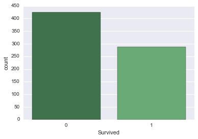

```python
sns.countplot(x="Survived", data=subdata, palette="Greens_d")
```

It looks like that there were more people dead than survived.

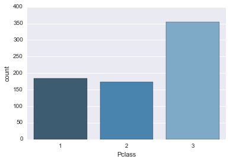

```python
sns.countplot(x="Pclass", data=subdata, palette="Blues_d")
```

So overall, it looks that there were more passengers in the 3rd class than in 1st class or 2nd class, but there was no difference between 1st and 2nd class.

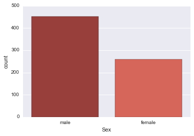

```python
sns.countplot(x="Sex", data=subdata, palette="Reds_d")
```

There were more male passengers than females.

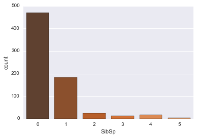

```python
sns.countplot(x="SibSp", data=subdata, palette='Oranges_d')
```

Most passengers had no siblings with them on board; Some had one sibling with them; very few of them had more than one sibling with them aboard.

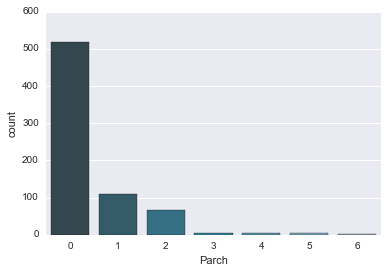

```python
sns.countplot(x="Parch", data=subdata, palette='PuBuGn_d')
```

Most passengers had no parents/children with them on board; Some had one or two parents/children with them; very few of them had more than two parents/children with them aboard.

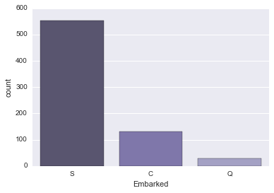

```python
sns.countplot(x="Embarked", data=subdata, palette="Purples_d")
```

Most passengers embarked at Southampton; for the rest of them, more passengers embarked at Cherbourg compared to Queenstown.

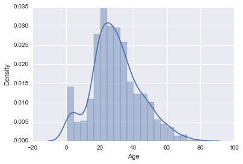

```python
sns.distplot(subdata['Age'])
plt.ylabel('Density')
```

Overall, most passengers were in their twenties to forties. The distribution of age looks like normal.

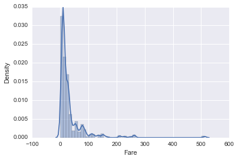

```python
sns.distplot(subdata['Fare'])
plt.ylabel('Density')
```

Most tickets were priced around 10-20. The distribution is positively skewed, which reflects the distribution of class (3rd class had most passengers).

### 4. Relationship Between the Variables

It is important to know the correlation between Survived and other variables, for we would like to see which factors are important for people's survival on titanic. Meanwhile, the correlations between the factors are also important, for we want to avoid the multicollinearity when we make the prediction. Therefore a heatmap including all variables of interest will be ideal for both purposes.

#### 4.1 Coding the categorical variables

To make the heatmap of all variables (excluding the PassengerId), the categorical variables should first be coded in numbers.

```python
titanic['Sex'] = titanic['Sex'].replace(['male', 'female'], ['1','0'])
titanic['Sex'] = titanic['Sex'].astype('int64')
```

```python
titanic['Embarked'] = titanic['Embarked'].replace(['S', 'C', 'Q'], ['1', '2', '3'])
titanic['Embarked'] = titanic['Embarked'].dropna().astype('int64')
```

```python
subdata = titanic[titanic['Age'].notnull() & titanic['Embarked'].notnull()]
subdata.head()
```

|  | PassengerId | Survived | Pclass | Name | Sex | Age | SibSp | Parch | Ticket | Fare | Cabin | Embarked |
| --- | --- | --- | --- | --- | --- | --- | --- | --- | --- | --- | --- | --- |
| 0 | 1 | 0 | 3 | Braund, Mr. Owen Harris | 1 | 22.0 | 1 | 0 | A/5 21171 | 7.2500 | NaN | 1.0 |
| 1 | 2 | 1 | 1 | Cumings, Mrs. John Bradley (Florence Briggs Th... | 0 | 38.0 | 1 | 0 | PC 17599 | 71.2833 | C85 | 2.0 |
| 2 | 3 | 1 | 3 | Heikkinen, Miss. Laina | 0 | 26.0 | 0 | 0 | STON/O2. 3101282 | 7.9250 | NaN | 1.0 |
| 3 | 4 | 1 | 1 | Futrelle, Mrs. Jacques Heath (Lily May Peel) | 0 | 35.0 | 1 | 0 | 113803 | 53.1000 | C123 | 1.0 |
| 4 | 5 | 0 | 3 | Allen, Mr. William Henry | 1 | 35.0 | 0 | 0 | 373450 | 8.0500 | NaN | 1.0 |

```python
len(subdata)
```

```
712
```

#### 4.2 Making correlation matrix and heatmap

```python
corr = subdata.corr()
corr
```

|  | PassengerId | Survived | Pclass | Sex | Age | SibSp | Parch | Fare | Embarked |
| --- | --- | --- | --- | --- | --- | --- | --- | --- | --- |
| PassengerId | 1.000000 | 0.029526 | -0.035609 | 0.024674 | 0.033681 | -0.082704 | -0.011672 | 0.009655 | -0.013757 |
| Survived | 0.029526 | 1.000000 | -0.356462 | -0.536762 | -0.082446 | -0.015523 | 0.095265 | 0.266100 | 0.108517 |
| Pclass | -0.035609 | -0.356462 | 1.000000 | 0.150826 | -0.365902 | 0.065187 | 0.023666 | -0.552893 | -0.108502 |
| Sex | 0.024674 | -0.536762 | 0.150826 | 1.000000 | 0.099037 | -0.106296 | -0.249543 | -0.182457 | -0.097129 |
| Age | 0.033681 | -0.082446 | -0.365902 | 0.099037 | 1.000000 | -0.307351 | -0.187896 | 0.093143 | 0.012186 |
| SibSp | -0.082704 | -0.015523 | 0.065187 | -0.106296 | -0.307351 | 1.000000 | 0.383338 | 0.139860 | 0.004021 |
| Parch | -0.011672 | 0.095265 | 0.023666 | -0.249543 | -0.187896 | 0.383338 | 1.000000 | 0.206624 | -0.014082 |
| Fare | 0.009655 | 0.266100 | -0.552893 | -0.182457 | 0.093143 | 0.139860 | 0.206624 | 1.000000 | 0.176859 |
| Embarked | -0.013757 | 0.108517 | -0.108502 | -0.097129 | 0.012186 | 0.004021 | -0.014082 | 0.176859 | 1.000000 |

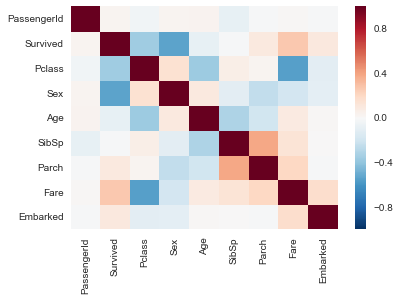

```python
sns.heatmap(corr,
            xticklabels=corr.columns.values,
            yticklabels=corr.columns.values)
```

From the heatmap, the Survived is negatively correlated to Pclass and Sex, and positively correlated to Fare and Embarked. Put it in words, it means that passengers who spent more on passenger fare and were in higher classes were more likely to survive, and female passengers were more likely to survive compared to males. In addition, passengers who got on board from Southampton were more likely to die compared passengers who got on board from other ports. But this relationship is weak compared to others, and may be due to the fact that passengers from Southampton outnumbered passengers from the other two ports.

Among the four variable correlated to Survived, it is noteworthy that Fare is negatively correlated to Pclass. This is reasonable since usually higher passenger class has higher price. This correlation needs to be considered in our further analysis.

```
 <a list of 2 Text xticklabel objects>)
```

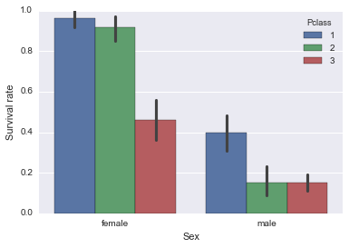

```python
sns.barplot(x="Sex", y="Survived", hue="Pclass", data=subdata)
plt.ylabel('Survival rate')
plt.xticks([0, 1], ['female', 'male'])
```

```
 <a list of 2 Text xticklabel objects>)
```

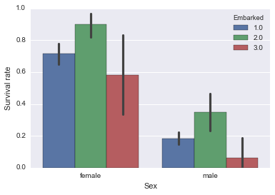

```python
sns.barplot(x="Sex", y="Survived", hue="Embarked", data=subdata)
plt.ylabel('Survival rate')
plt.xticks([0, 1], ['female', 'male'])
```

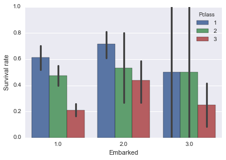

```python
sns.barplot(x="Embarked", y="Survived", hue="Pclass", data=subdata)
plt.ylabel('Survival rate')
```

These three plots described the relationship between Sex, Pclass, Embarked and Survived. It looks like that there are interactions between Sex and Pclass, and Pclass and Embarked, both of which need to be considered in further analysis.

### 5. Logistic Regression to Predict Survival

```python
m1 = smf.logit(formula='Survived ~ Pclass + Sex + Fare + Embarked', data=subdata).fit()
print(m1.summary())
```

```
Optimization terminated successfully.
         Current function value: 0.470926
         Iterations 6
                           Logit Regression Results
==============================================================================
Dep. Variable:               Survived   No. Observations:                  712
Model:                          Logit   Df Residuals:                      707
Method:                           MLE   Df Model:                            4
Date:                Tue, 03 Jan 2017   Pseudo R-squ.:                  0.3021
Time:                        00:29:45   Log-Likelihood:                -335.30
converged:                       True   LL-Null:                       -480.45
                                        LLR p-value:                 1.336e-61
==============================================================================
                 coef    std err          z      P>|z|      [95.0% Conf. Int.]
------------------------------------------------------------------------------
Intercept      2.9311      0.456      6.429      0.000         2.038     3.825
Pclass        -0.9290      0.137     -6.789      0.000        -1.197    -0.661
Sex           -2.5449      0.204    -12.480      0.000        -2.945    -2.145
Fare           0.0016      0.002      0.716      0.474        -0.003     0.006
Embarked       0.1639      0.184      0.893      0.372        -0.196     0.524
==============================================================================
```

From the results of m1, the Log-Likelihood of the model is -335.30, p < .001, which means that the model is effective to predict survival on titanic, with Pseudo R Square = 0.3021. However, from the regression coefficients we could see that the p value for Fare and Embarked are larger than .05, which means they are not good predictors. As mentioned above, Fare is negatively correlated to Pclass, which means it probably should not be in the model. And as mentioned above, embarked is probably not a good predictor since there are a lot more people who embarked from Southampton compared to the other two ports, and this intuitive thinking is supported by the model here. So in Model 2, Fare and Embarked are excluded.

```python
m2 = smf.logit(formula='Survived ~ Pclass + Sex', data=subdata).fit()
print(m2.summary())
```

```
Optimization terminated successfully.
         Current function value: 0.472013
         Iterations 6
                           Logit Regression Results
==============================================================================
Dep. Variable:               Survived   No. Observations:                  712
Model:                          Logit   Df Residuals:                      709
Method:                           MLE   Df Model:                            2
Date:                Tue, 03 Jan 2017   Pseudo R-squ.:                  0.3005
Time:                        00:37:54   Log-Likelihood:                -336.07
converged:                       True   LL-Null:                       -480.45
                                        LLR p-value:                 1.982e-63
==============================================================================
                 coef    std err          z      P>|z|      [95.0% Conf. Int.]
------------------------------------------------------------------------------
Intercept      3.3344      0.324     10.296      0.000         2.700     3.969
Pclass        -0.9876      0.118     -8.345      0.000        -1.220    -0.756
Sex           -2.5683      0.203    -12.644      0.000        -2.966    -2.170
==============================================================================
```

In Model 2, the Log-Likelihood is -336.07, p < .001, which means that the model is effective to predict survival on titanic, with Pseudo R Square = 0.3005. From the results we can see that without the variables Fare and Embarked, the model is equally effective compared to Model 1. Therefore Model 2 is better.

```python
m3 = smf.logit(formula='Survived ~ Sex*Pclass', data=subdata).fit()
print(m3.summary())
```

```
Optimization terminated successfully.
         Current function value: 0.456149
         Iterations 7
                           Logit Regression Results
==============================================================================
Dep. Variable:               Survived   No. Observations:                  712
Model:                          Logit   Df Residuals:                      708
Method:                           MLE   Df Model:                            3
Date:                Tue, 03 Jan 2017   Pseudo R-squ.:                  0.3240
Time:                        00:45:17   Log-Likelihood:                -324.78
converged:                       True   LL-Null:                       -480.45
                                        LLR p-value:                 3.481e-67
==============================================================================
                 coef    std err          z      P>|z|      [95.0% Conf. Int.]
------------------------------------------------------------------------------
Intercept      6.0889      0.854      7.130      0.000         4.415     7.763
Sex           -6.0340      0.910     -6.634      0.000        -7.817    -4.251
Pclass        -2.0617      0.311     -6.624      0.000        -2.672    -1.452
Sex:Pclass     1.4249      0.341      4.183      0.000         0.757     2.093
==============================================================================
```

With the interaction between Sex and Pclass added, Model 3 seems to be a better model, for the Log-Likelihood is -324.78, p < .001, with Pseudo R Square = 0.3240. All the regression coefficients of predictors are significant. Therefore Model 3 is better than Model 2.

```python
print ('Odds Ratio')
print (np.exp(m3.params))
```

```
Odds Ratio
Intercept     440.952431
Pclass          0.127232
Sex             0.002396
Sex:Pclass      4.157307
dtype: float64
```

```python
params = m3.params
conf = m3.conf_int()
conf['Odds Ratio'] = params
conf.columns = ['Lower CI', 'Upper CI', 'Odds Ratio']
print(np.exp(conf))
```

```
             Lower CI     Upper CI  Odds Ratio
Intercept   82.686830  2351.511693  440.952431
Pclass       0.069126     0.234183    0.127232
Sex          0.000403     0.014245    0.002396
Sex:Pclass   2.132344     8.105262    4.157307
```

### 6. Conclusions

In general, we found that passengers' class and sex are crucial factors to passengers' survival on titanic. In addition, the interaction between passengers' sex and class also have impact on passengers' survival. Overall, female passengers and passengers of higher class were more likely to survive.